# Lista de Exercícios 5

### No Exemplo 16 do livro texto, um passo de tempo de 1 fs e uma frequência de escalonamento das velocidades de 0,1 ps (fase de equilibração) foram usados para integrar as equações dinâmicas. Repita as simulações para o mesmo tempo total de simulação, mas usando:

### (a) Diferentes passos de tempo (menores e maiores do que 1 fs);

### (b) Diferentes parâmetros de acoplamento do termostato na fase de equilibração (menores e maiores que 0,1 ps);

### Para os itens a) e b), discuta como os resultados mudam em comparação aos resultados do Exemplo 16. A conservação de energia é substancialmente melhor? Como os valores dos ângulos diedros mudam (veja Seção 9.4 e Exemplo 17)? Existem maneiras melhores de comparar as diferentes trajetórias?

```python
from Definitions import *
import pandas as pd
import matplotlib.pyplot as plt
import seaborn as sns
import numpy as np
```

```python
# Define the energy models
mmModel = MMModelOPLS.WithParameterSet("bookSmallExamples")
nbModel = NBModelFull.WithDefaults()

# Generate the molecule
molecule = ImportSystem(os.path.join(molPath, "bala_c7eq.mol"))
molecule.DefineMMModel(mmModel)
molecule.DefineNBModel(nbModel)
molecule.Summary()
molecule.Energy()
```

```
System imported from "~/Programs/pDynamo3/pDynamo3-main/examples/book/data/mol/bala_c7eq.mol" in MDL MOL format.

--------------------------------------------------------------------------------------------------------
                          Summary of System "bALA C7 equatorial configuration"
--------------------------------------------------------------------------------------------------------
------------------------------------------------- Atoms ------------------------------------------------
Atoms                           =                22  Heavy Atoms                     =                10
Hydrogens                       =                12
--------------------------------------------- Connectivity ---------------------------------------------
Angles                          =                36  Atoms                           =                22
Bonds                           =                21  Dihedrals                       =                41
Isolates                        =                 1  Ring Sets                       =                 0
--------------------------------------------- OPLS MM Model --------------------------------------------
1-4 Interactions                =                41  1-4 Lennard-Jones Form          =              OPLS
1-4 Lennard-Jones Types         =                 6  Electrostatic 1-4 Scaling       =             0.500
Exclusions                      =                98  Fourier Dihedral Parameters     =                18
Fourier Dihedral Terms          =                29  Fourier Out-Of-Plane Parameters =                 2
Fourier Out-Of-Plane Terms      =                12  Harmonic Angle Parameters       =                13
Harmonic Angle Terms            =                36  Harmonic Bond Parameters        =                 7
Harmonic Bond Terms             =                21  Lennard-Jones Form              =              OPLS
Lennard-Jones Types             =                 6  Number of MM Atom Types         =                 6
Number of MM Atoms              =                22  Parameter Set                   = bookSmallExamples
Total MM Charge                 =              0.00
--------------------------------------------- Full NB Model --------------------------------------------
Damping Cut-Off                 =             0.500  Dielectric                      =             1.000
--------------------------------------------------------------------------------------------------------

------------------------------- Summary of Energy Terms ------------------------------
Potential Energy        =        -168.0306  RMS Gradient            =             None
Fourier Dihedral        =          14.9277  Fourier Out-Of-Plane    =           0.2528
Harmonic Angle          =           3.2424  Harmonic Bond           =           0.9582
MM/MM 1-4 Electrostatic =         103.2125  MM/MM 1-4 Lennard-Jones =          15.5290
MM/MM Electrostatic     =        -303.4207  MM/MM Lennard-Jones     =          -2.7325
--------------------------------------------------------------------------------------
```

```
-168.03056528811538
```

```python
def molecular_simulation(molecule=molecule, time_step=0.001, temperature_scale_frequency=100):

    # Optimization
    ConjugateGradientMinimize_SystemGeometry(molecule,
                                             maximumIterations=2000,
                                             logFrequency=100,
                                             rmsGradientTolerance=0.1)

    # Define a random number generator in a given state
    normalDeviateGenerator = NormalDeviateGenerator.WithRandomNumberGenerator(RandomNumberGenerator.WithSeed(14835))

    # Heating
    VelocityVerletDynamics_SystemGeometry(molecule,
                                          logFrequency=100,
                                          normalDeviateGenerator=normalDeviateGenerator,
                                          steps=1000,
                                          timeStep=time_step,
                                          temperatureScaleFrequency=temperature_scale_frequency,
                                          temperatureScaleOption="linear",
                                          temperatureStart=10.0,
                                          temperatureStop=300.0)

    # Equilibration
    VelocityVerletDynamics_SystemGeometry(molecule,
                                          logFrequency=500,
                                          steps=5000,
                                          timeStep=time_step,
                                          temperatureScaleFrequency=temperature_scale_frequency,
                                          temperatureScaleOption="constant",
                                          temperatureStart=300.0)

    # Data-collection
    trajectory_open = ExportTrajectory(f"bala_simulation/bala_c7eq_{time_step}_{temperature_scale_frequency}.ptGeo",
                                       molecule)
    VelocityVerletDynamics_SystemGeometry(molecule,
                                          logFrequency=500,
                                          steps=10000,
                                          timeStep=time_step,
                                          trajectories=[(trajectory_open, 100)])

    # importing trajectory
    trajectory = ImportTrajectory(f"bala_simulation/bala_c7eq_{time_step}_{temperature_scale_frequency}.ptGeo",
                                  molecule)
    trajectory.ReadHeader()

    # Loop over the frames in the trajectory to gather phi and psi angles
    phi = []
    psi = []
    while trajectory.RestoreOwnerData():
        phi.append(molecule.coordinates3.Dihedral(4, 6,  8, 14))
        psi.append(molecule.coordinates3.Dihedral(6, 8, 14, 16))

    # . Finish up.
    trajectory.ReadFooter()
    trajectory.Close()

    return {f"{time_step}_{temperature_scale_frequency}_phi": phi,
            f"{time_step}_{temperature_scale_frequency}_psi": psi}
```

## Mudando o time step

```python
# Changing the time step

time_steps_list = [0.0001, 0.001, 0.003]

result_change_time_step = {}

for step in time_steps_list:
    result_change_time_step = result_change_time_step | molecular_simulation(time_step=step)
```

```
-------------------- Summary of Conjugate Gradient Minimizer -------------------
Beta Type                  =          1  Initial Step               =        0.1
Log Frequency              =        100  Maximum Iterations         =       2000
Maximum Theta              =      1e+10  Minimum Theta              =      1e-10
RMS Gradient Tolerance     =        0.1  Steepest Descent Tolerance =      0.001
Use Spectral Theta         =       True
--------------------------------------------------------------------------------

----------------------------------------------------------------------------------------------------------------
  Iteration       Function          RMS Gradient        Max. |Grad.|          RMS Disp.         Max. |Disp.|
----------------------------------------------------------------------------------------------------------------
     0     I       -168.03056529          2.94590251          9.69653103          0.01230915          0.04051595
----------------------------------------------------------------------------------------------------------------

Minimization converged.

-------------------- Conjugate Gradient Minimizer Statistics -------------------
Function Calls           =           77  Iterations               =           41
--------------------------------------------------------------------------------

--------------------- Summary of Velocity Verlet Integrator --------------------
Log Frequency               =       100  Maximum Iterations          =      1000
Temperature Handling        =    Linear  Temperature Scale           =      2900
Temperature Scale Frequency =       100  Temperature Start           =        10
Temperature Stop            =       300  Time Step                   =    0.0001
--------------------------------------------------------------------------------

----------------------------------------------------------------------------------------------------
                                 Velocity Verlet Integrator Results
----------------------------------------------------------------------------------------------------
        Time            Total Energy       Kinetic Energy     Potential Energy       Temperature
----------------------------------------------------------------------------------------------------
          0.00000000       -165.94237896          2.49434181       -168.43672076         10.00000000
          0.01000000       -157.81879819          9.72793305       -167.54673124         39.00000000
          0.02000000       -147.26252662         16.96152428       -164.22405090         68.00000000
          0.03000000       -134.23311801         24.19511552       -158.42823353         97.00000000
          0.04000000       -123.82466763         31.42870676       -155.25337439        126.00000000
          0.05000000       -116.52495229         38.66229800       -155.18725029        155.00000000
          0.06000000       -108.20862363         45.89588924       -154.10451287        184.00000000
          0.07000000        -97.32647339         53.12948048       -150.45595388        213.00000000
```

[output cut: 289 more lines]

```
         16.50000000         18.56744231         82.17131243        -63.60387012        329.43084310
         18.00000000         16.13204776         73.30536289        -57.17331513        293.88659845
         19.50000000         24.25302039         75.61833104        -51.36531065        303.15945809
         21.00000000         18.17505807         93.92612991        -75.75107184        376.55677205
         22.50000000         12.81295359         71.88056939        -59.06761580        288.17449636
         24.00000000         14.69147670         98.32656670        -83.63509000        394.19844722
         25.50000000         15.29735129         72.04898606        -56.75163477        288.84969122
         27.00000000         17.38003716         94.85511733        -77.47508017        380.28115103
         28.50000000         10.22640004         94.58501508        -84.35861504        379.19829123
         30.00000000         17.28542852         89.12802265        -71.84259413        357.32080667
Averages                     23.56721695         80.07531860        -56.50810165        321.02784947
RMS Deviations                7.66602313         10.31960103         14.68429195         41.37204053
----------------------------------------------------------------------------------------------------

Trajectory activated for import from "bala_simulation/bala_c7eq_0.003_100.ptGeo" in System Geometry Trajectory format.
```

### Resumo dos Resultados:

```
time step = 0.0001
subindo temperatura:
                            Total Energy       Kinetic Energy     Potential Energy       Temperature
Averages                   -121.23472186         28.85673041       -150.09145226        115.68875737
RMS Deviations               28.74789772         18.71657128         12.09470237         75.03611266

temperatura estável em 300K:
                            Total Energy       Kinetic Energy     Potential Energy       Temperature
Averages                    -43.83543301         77.83603582       -121.67146882        312.05039987
RMS Deviations                7.70555735         10.75278548          9.05853972         43.10870888

sem controle temperatura:
                            Total Energy       Kinetic Energy     Potential Energy       Temperature
Averages                    -48.31484083         73.07568004       -121.39052087        292.96578298
RMS Deviations                0.00528886          8.64274157          8.64682227         34.64938745

====================================================================================================

time step = 0.001
subindo temperatura:
                            Total Energy       Kinetic Energy     Potential Energy       Temperature
Averages                   -110.49875385         28.51088114       -139.00963498        114.30222217
RMS Deviations               37.89726000         20.21597729         20.65529778         81.04734175

temperatura estável em 300K:
                            Total Energy       Kinetic Energy     Potential Energy       Temperature
Averages                    -18.30627276         75.29415838        -93.60043114        301.85982604
RMS Deviations               10.27281747         11.54427631         11.81489651         46.28185391

sem controle temperatura:
                            Total Energy       Kinetic Energy     Potential Energy       Temperature
Averages                    -17.98027194         73.88222684        -91.86249878        296.19928850
RMS Deviations                0.35653233          9.20481904          9.42545882         36.90279742

====================================================================================================

time step = 0.003
subindo temperatura:
                            Total Energy       Kinetic Energy     Potential Energy       Temperature
Averages                   -101.11505588         28.54471693       -129.65977281        114.43787237
RMS Deviations               47.62667764         21.04380337         28.31340768         84.36615748

temperatura estável em 300K:
                            Total Energy       Kinetic Energy     Potential Energy       Temperature
Averages                      1.26364279         73.75312042        -72.48947764        295.68169137
RMS Deviations               15.52935209         11.20955079         15.30705206         44.93991464

sem controle temperatura:
                            Total Energy       Kinetic Energy     Potential Energy       Temperature
Averages                     23.56721695         80.07531860        -56.50810165        321.02784947
RMS Deviations                7.66602313         10.31960103         14.68429195         41.37204053
```

### Conforme aumentamos o tamanho do passo, percebemos que os valores de RMS Deviation aumentam em todas as dinâmicas.

```python
molecular_simulation(time_step=0.004)
```

```
-------------------- Summary of Conjugate Gradient Minimizer -------------------
Beta Type                  =          1  Initial Step               =        0.1
Log Frequency              =        100  Maximum Iterations         =       2000
Maximum Theta              =      1e+10  Minimum Theta              =      1e-10
RMS Gradient Tolerance     =        0.1  Steepest Descent Tolerance =      0.001
Use Spectral Theta         =       True
--------------------------------------------------------------------------------

----------------------------------------------------------------------------------------------------------------
  Iteration       Function          RMS Gradient        Max. |Grad.|          RMS Disp.         Max. |Disp.|
----------------------------------------------------------------------------------------------------------------
     0     I       -116.80736476         61.03784526        257.71831361          0.01230915          0.05197256
   100   L0s       -168.34928845          1.07102945          3.30604423          0.00320647          0.01350617
----------------------------------------------------------------------------------------------------------------

Minimization converged.

-------------------- Conjugate Gradient Minimizer Statistics -------------------
Function Calls          =           303  Iterations              =           174
--------------------------------------------------------------------------------

--------------------- Summary of Velocity Verlet Integrator --------------------
Log Frequency               =       100  Maximum Iterations          =      1000
Temperature Handling        =    Linear  Temperature Scale           =      72.5
Temperature Scale Frequency =       100  Temperature Start           =        10
Temperature Stop            =       300  Time Step                   =     0.004
--------------------------------------------------------------------------------

----------------------------------------------------------------------------------------------------
                                 Velocity Verlet Integrator Results
----------------------------------------------------------------------------------------------------
        Time            Total Energy       Kinetic Energy     Potential Energy       Temperature
----------------------------------------------------------------------------------------------------
          0.00000000       -165.94780282          2.49434181       -168.44214463         10.00000000
          0.400000002427437929497647906792291988066118178152945652187755076575783881361367178291790674382500784515203024748280465370120192.00000000          9.727933052427437929497647906792291988066118178152945652187755076575783881361367178291790674382500784515203024748280465370120192.00000000      …
```

```
---------------------------------------------------------------------------
OverflowError                             Traceback (most recent call last)
Cell In [11], line 1
----> 1 molecular_simulation(time_step=0.004)

Cell In [4], line 13, in molecular_simulation(molecule, time_step, temperature_scale_frequency)
     10 normalDeviateGenerator = NormalDeviateGenerator.WithRandomNumberGenerator(RandomNumberGenerator.WithSeed(14835))
     12 # Heating
---> 13 VelocityVerletDynamics_SystemGeometry(molecule,
     14                                       logFrequency=100,
     15                                       normalDeviateGenerator=normalDeviateGenerator,
     16                                       steps=1000,
     17                                       timeStep=time_step,
     18                                       temperatureScaleFrequency=temperature_scale_frequency,
     19                                       temperatureScaleOption="linear",
     20                                       temperatureStart=10.0,
     21                                       temperatureStop=300.0)
     23 # Equilibration
     24 VelocityVerletDynamics_SystemGeometry(molecule,
     25                                       logFrequency=500,
     26                                       steps=5000,
   (...)
     29                                       temperatureScaleOption="constant",
     30                                       temperatureStart=300.0)

File ~/Programs/pDynamo3/pDynamo3-main/pSimulation/MolecularDynamics.py:80, in VelocityVerletDynamics_SystemGeometry(system, **options)
     78 optimizer = VelocityVerletIntegrator.WithOptions ( **options )
     79 optimizer.Summary ( log = log )
---> 80 return optimizer.Iterate ( of, log = log )

File ~/Programs/pDynamo3/pDynamo3-main/pScientific/ObjectiveFunctionIterators/ObjectiveFunctionIterator.py:98, in ObjectiveFunctionIterator.Iterate(self, objectiveFunction, log)
     96 while ( self.Continue ( state ) ):
     97     self.Iteration    ( state )
---> 98     self.LogIteration ( state )
     99 self.LogStop ( state )
    100 return state.Finalize ( )

File ~/Programs/pDynamo3/pDynamo3-main/pScientific/ObjectiveFunctionIterators/MultiDimensionalDynamics.py:96, in MultiDimensionalDynamics.LogIteration(self, state)
     94     values.append ( value )
     95     state.averages     [i] += value
---> 96     state.rmsDeviations[i] += value**2
     97 state.numberOfSamples += 1
     98 # . Output.

OverflowError: (34, 'Numerical result out of range')
```

### Análise dos ângulos diedrais

```python
results_time_step_df = pd.DataFrame.from_dict(result_change_time_step)
results_time_step_df.head()
```

|  | 0.0001_100_phi | 0.0001_100_psi | 0.001_100_phi | 0.001_100_psi | 0.003_100_phi | 0.003_100_psi |
| --- | --- | --- | --- | --- | --- | --- |
| 0 | -102.356330 | 93.340931 | -84.575350 | 48.838702 | -90.963210 | 97.628332 |
| 1 | -101.840590 | 94.850791 | -89.418396 | 55.624992 | -79.736878 | 60.029901 |
| 2 | -103.397849 | 95.037325 | -68.868610 | 66.535402 | -75.561998 | 76.827294 |
| 3 | -98.110777 | 92.086078 | -74.088959 | 85.217799 | -75.551192 | 75.861844 |
| 4 | -99.131983 | 91.163685 | -80.438757 | 84.967025 | -77.061581 | 65.098220 |

```python
def diedral_analise(time_step, ax):
    ax.scatter(results_time_step_df[f"{time_step}_100_phi"],
               results_time_step_df[f"{time_step}_100_psi"],
               edgecolors='k',
               alpha=0.85,
               linewidths=0.6)

    ax.set_title(f"Time Step = {time_step} fs")
    ax.set_xlabel("Φ Angle (º)")
    ax.set_ylabel("Ψ Angle (º)")

    ax.set_ylim(-200, 200)
    ax.set_xlim(-200, 200)
```

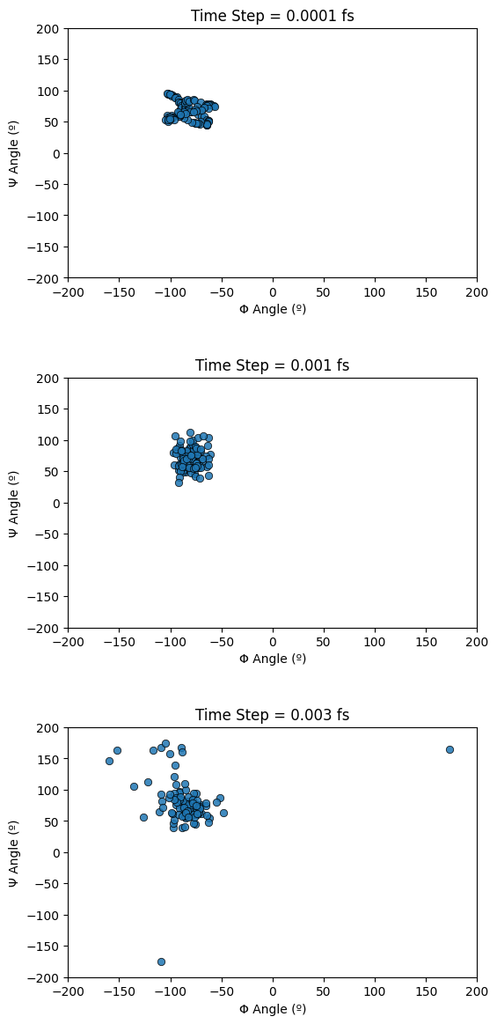

```python
fig, axs = plt.subplots(3, 1, figsize=(6, 14))

for step, ax in zip(time_steps_list, range(3)):
    diedral_analise(step, ax=axs[ax])

plt.subplots_adjust(hspace=0.4)
plt.show()
```

### Isto faz sentido físico, posto que, com menores time steps, os movimentos são calculados em um intervalo de tempo menor, causando mudanças mais sutis nas geometrias.

## Mudando o temperature scale frequency

```python
# Changing the temperature scale frequencies

temperature_scale_frequencies_list = [1, 10, 100, 200]

result_change_temperature_scale = {}

for temp_scale in temperature_scale_frequencies_list:
    result_change_temperature_scale = result_change_temperature_scale | molecular_simulation(temperature_scale_frequency=temp_scale)
```

```
-------------------- Summary of Conjugate Gradient Minimizer -------------------
Beta Type                  =          1  Initial Step               =        0.1
Log Frequency              =        100  Maximum Iterations         =       2000
Maximum Theta              =      1e+10  Minimum Theta              =      1e-10
RMS Gradient Tolerance     =        0.1  Steepest Descent Tolerance =      0.001
Use Spectral Theta         =       True
--------------------------------------------------------------------------------

----------------------------------------------------------------------------------------------------------------
  Iteration       Function          RMS Gradient        Max. |Grad.|          RMS Disp.         Max. |Disp.|
----------------------------------------------------------------------------------------------------------------
     0     I        -71.84259413         89.65972829        314.53136622          0.01230915          0.04318119
   100   L0s       -164.86068200          0.94216324          2.91378331          0.00134620          0.00470281
   200   L1s       -165.03282192          0.13290365          0.33788390          0.00020773          0.00065435
----------------------------------------------------------------------------------------------------------------

Minimization converged.

-------------------- Conjugate Gradient Minimizer Statistics -------------------
Function Calls          =           439  Iterations              =           243
--------------------------------------------------------------------------------

--------------------- Summary of Velocity Verlet Integrator --------------------
Log Frequency               =       100  Maximum Iterations          =      1000
Temperature Handling        =    Linear  Temperature Scale           =       290
Temperature Scale Frequency =         1  Temperature Start           =        10
Temperature Stop            =       300  Time Step                   =     0.001
--------------------------------------------------------------------------------

----------------------------------------------------------------------------------------------------
                                 Velocity Verlet Integrator Results
----------------------------------------------------------------------------------------------------
        Time            Total Energy       Kinetic Energy     Potential Energy       Temperature
----------------------------------------------------------------------------------------------------
          0.00000000       -162.55009880          2.49434181       -165.04444061         10.00000000
          0.10000000       -142.17404605          9.72793305       -151.90197909         39.00000000
          0.20000000       -135.95439306         16.96152428       -152.91591734         68.00000000
          0.30000000       -110.62173652         24.19511552       -134.81685204         97.00000000
          0.40000000       -108.92490357         31.42870676       -140.35361033        126.00000000
          0.50000000        -99.79113104         38.66229800       -138.45342904        155.00000000
```

[output cut: 408 more lines]

```
          5.50000000          2.52424409         80.66324566        -78.13900157        323.38489235
          6.00000000          2.95553269         77.06770707        -74.11217437        308.97011332
          6.50000000          3.41037107         78.93828414        -75.52791307        316.46939458
          7.00000000          3.22690535         73.78016034        -70.55325499        295.79009640
          7.50000000          2.08843921         98.40855658        -96.32011737        394.52715068
          8.00000000          2.31001194         83.75862819        -81.44861625        335.79450886
          8.50000000          2.63926895         84.50851267        -81.86924372        338.80085098
          9.00000000          2.48660842         74.31952765        -71.83291922        297.95245964
          9.50000000          2.29544463         87.28714011        -84.99169548        349.94057301
         10.00000000          3.81112445         67.49790745        -63.68678300        270.60408188
Averages                      2.76376521         83.49864003        -80.73487482        334.75219719
RMS Deviations                0.54784355         11.15921515         11.52930857         44.73811538
----------------------------------------------------------------------------------------------------

Trajectory activated for import from "bala_simulation/bala_c7eq_0.001_200.ptGeo" in System Geometry Trajectory format.
```

### Resumo dos Resultados:

```
temperature scale frequency = 1
subindo temperatura:
                            Total Energy       Kinetic Energy     Potential Energy       Temperature
Averages                    -93.58228355         38.66229800       -132.24458155        155.00000000
RMS Deviations               38.00679198         20.90245039         18.27314903         83.79946301

temperatura estável em 300K:
                            Total Energy       Kinetic Energy     Potential Energy       Temperature
Averages                    -15.41461403         74.83025420        -90.24486823        300.00000000
RMS Deviations               20.37158092          0.00000000         20.37158092          0.00000000

sem controle temperatura:
                            Total Energy       Kinetic Energy     Potential Energy       Temperature
Averages                     21.81135050         93.60934425        -71.79799375        375.28675501
RMS Deviations                0.36476646         12.98770179         13.14869985         52.06865298

====================================================================================================

temperature scale frequency = 10
subindo temperatura:
                            Total Energy       Kinetic Energy     Potential Energy       Temperature
Averages                   -102.65105686         38.27378591       -140.92484276        153.44242640
RMS Deviations               30.75150950         21.04171562         11.45162824         84.35778755

temperatura estável em 300K:
                            Total Energy       Kinetic Energy     Potential Energy       Temperature
Averages                    -43.13238663         75.07308591       -118.20547255        300.97353023
RMS Deviations                6.61812686          6.19761845          6.50578494         24.84670879

sem controle temperatura:
                            Total Energy       Kinetic Energy     Potential Energy       Temperature
Averages                    -48.36735325         60.53648689       -108.90384014        242.69523419
RMS Deviations                0.23057522          8.12165740          8.22899071         32.56032262

====================================================================================================

temperature scale frequency = 100
subindo temperatura:
                            Total Energy       Kinetic Energy     Potential Energy       Temperature
Averages                   -106.22836568         29.10093417       -135.32929986        116.66778826
RMS Deviations               42.63858104         21.99509109         22.87177237         88.17994002

temperatura estável em 300K:
                            Total Energy       Kinetic Energy     Potential Energy       Temperature
Averages                     -8.23415319         77.42193394        -85.65608713        310.39023496
RMS Deviations               14.15085147         11.97719483         12.51584532         48.01745614

sem controle temperatura:
                            Total Energy       Kinetic Energy     Potential Energy       Temperature
Averages                     -0.63746879         80.99679633        -81.63426512        324.72212155
RMS Deviations                0.42634887          9.94475487         10.21948439         39.86925465

====================================================================================================

temperature scale frequency = 200
subindo temperatura:
                            Total Energy       Kinetic Energy     Potential Energy       Temperature
Averages                   -124.51015653         19.80382283       -144.31397936         79.39498418
RMS Deviations               28.46451582         14.90171281         15.64323342         59.74206408

temperatura estável em 300K:
                            Total Energy       Kinetic Energy     Potential Energy       Temperature
Averages                    -19.00226928         72.29381678        -91.29608606        289.83123561
RMS Deviations               15.82691412         12.85810300         12.97326054         51.54908187

sem controle temperatura:
                            Total Energy       Kinetic Energy     Potential Energy       Temperature
Averages                      2.76376521         83.49864003        -80.73487482        334.75219719
RMS Deviations                0.54784355         11.15921515         11.52930857         44.73811538
```

### Conforme esperado, percebemos que o RMS Deviation da energia cinética e da temperatura, nas simulações de equilibração, aumentam junto com o temperature scale frequency. Isso faz bastante sentido, posto que, ao aumentar este parâmetro, a temperatura é ajustada menos frequentemente, aumentando a variação.

### É interessante notar que, quando o scale factor é 1, e há controle constante de temperatura, tanto a temperatura quanto a energia cinética têm RMS Deviations de 0. Isso ocorre por que a temperatura é ajustada em todos os passos.

### Análise dos Ângulos Diedrais

```python
results_scale_freq_df = pd.DataFrame.from_dict(result_change_temperature_scale)
results_scale_freq_df.head()
```

|  | 0.001_1_phi | 0.001_1_psi | 0.001_10_phi | 0.001_10_psi | 0.001_100_phi | 0.001_100_psi | 0.001_200_phi | 0.001_200_psi |
| --- | --- | --- | --- | --- | --- | --- | --- | --- |
| 0 | 176.004237 | 165.600913 | -143.518664 | 159.711376 | -158.356433 | 133.798911 | -146.256746 | 167.329928 |
| 1 | -139.294567 | 170.685030 | -151.978516 | 148.178061 | -151.823087 | 142.546117 | -144.112758 | 165.061647 |
| 2 | -97.327192 | 163.013479 | -129.193334 | 162.591411 | -116.149159 | 177.746989 | -133.223382 | 156.991919 |
| 3 | -86.871989 | 141.498558 | -123.403223 | 166.955426 | -98.828095 | -171.696330 | -130.610307 | 162.382994 |
| 4 | -39.186886 | 96.946967 | -121.722851 | 170.662587 | -99.835596 | 173.135644 | -123.904253 | 158.843969 |

```python
def diedral_analise_temp(temp_scale, ax):
    ax.scatter(results_scale_freq_df[f"0.001_{temp_scale}_phi"],
               results_scale_freq_df[f"0.001_{temp_scale}_psi"],
               edgecolors='k',
               alpha=0.85,
               linewidths=0.6)

    ax.set_title(f"Temperature Scale Frequency = {temp_scale} steps")
    ax.set_xlabel("Φ Angle (º)")
    ax.set_ylabel("Ψ Angle (º)")

    ax.set_ylim(-200, 200)
    ax.set_xlim(-200, 200)
```

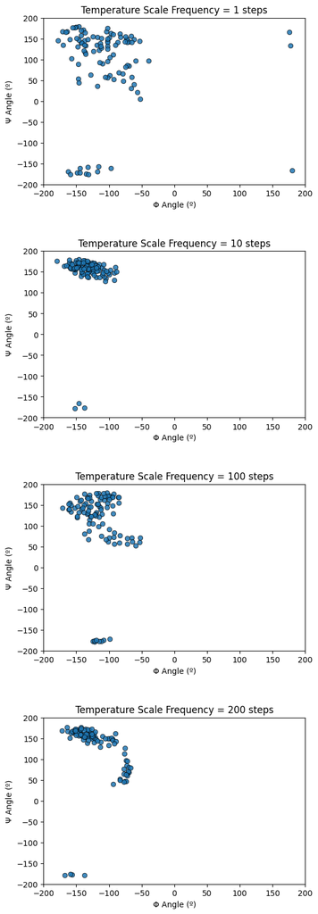

```python
fig, axs = plt.subplots(4, 1, figsize=(6, 20))

for temp, ax in zip(temperature_scale_frequencies_list, range(4)):
    diedral_analise_temp(temp, ax=axs[ax])

plt.subplots_adjust(hspace=0.4)
plt.show()
```

### Podemos ver que, com o temperature scale frequency de 1 step, a dispersão dos ângulos é bastante maior. Nesta simulação, o valor de 10 apresentou os ângulos mais compactos, enquanto 100 e 200 mostraram-se semelhantes.